Home > Supervised Learning > Regularized Linear Models

# 2.1.2 Regularized Linear Models

Now we will briefly discuss so-called regularized linear models. In the case of a very large number of input variables, one may only be interested in a few variables that have the strongest influence. Thus, the model becomes
$$\min_{\beta \in
\mathbb{R}^{n \times m}}\frac{1}{2}||X \beta - Y||^2 \text{ such that
most entries of }\beta \text{ are small or zero}$$
To enforce that the entries of $\beta$ are small, we add a penalty term and obtain

#### 2.1.4

$$\min_{\beta \in \mathbb{R}^{n \times
m}}\frac{1}{2}||X \beta - Y||^2 +
\frac{\lambda}{2}||\beta||^2$$
where $\lambda \geq 0$ is a freely selectable parameter. This model is also called Ridge Regression. Here, $|| \cdot ||$ denotes the Frobenius norms, but we omit the corresponding designation. What is remarkable about this model is that for all $\lambda > 0$, it has a unique solution, regardless of the invertibility of $X^TX$

#### Proposition 2.1.4

For all $\lambda > 0$, the problem 2.1.4 has a unique solution given by

#### Expanding

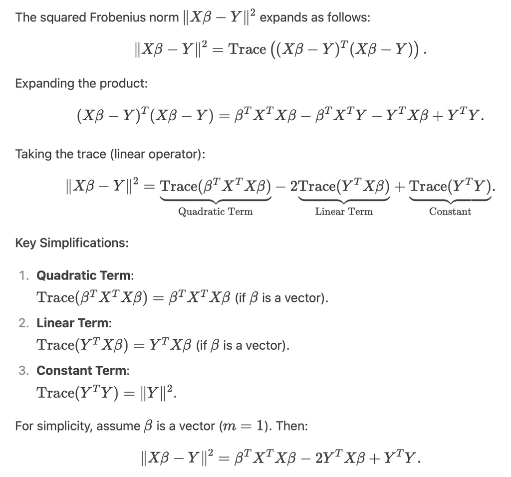

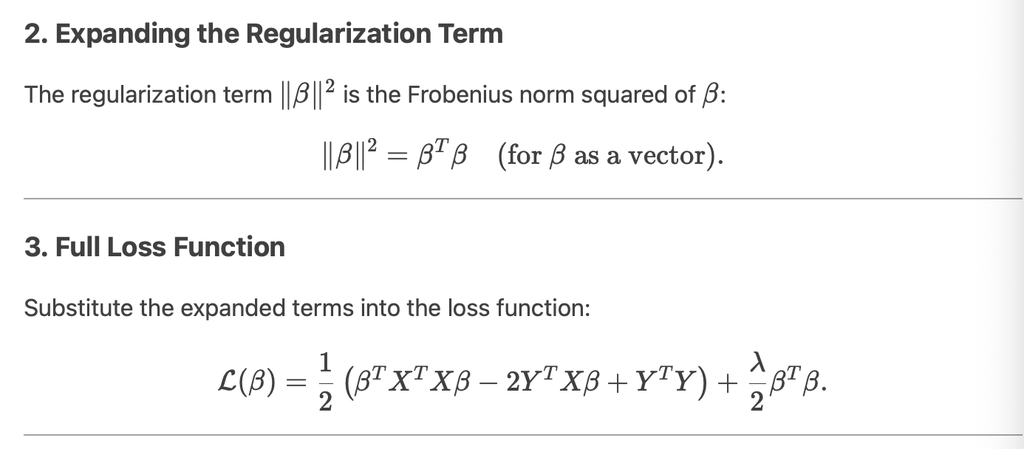

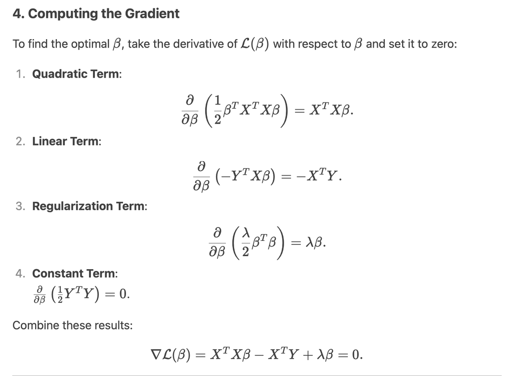

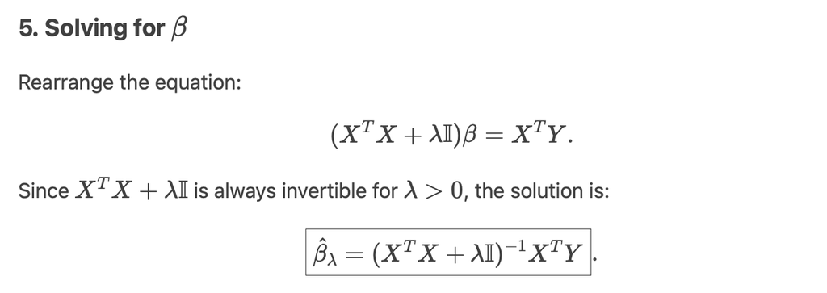

#### Proof

The objective function above 2.1.4 is convex, thus the optimality condition is

#### 2.1.6

$$0 = X^T (X\hat{\beta} - Y) + \lambda
\hat{\beta} = (X^TX + \lambda \mathbb{I})\hat{\beta}- X^TY$$
(Note that the first part $0 = X^T (X\hat{\beta} - Y) + \lambda \hat{\beta}$ is the gradient which must be 0)which is necessary and sufficient for minimality. We assert that the square matrix $X^TX + \lambda \mathbb{I}$ is invertible. To show this, it suffices to check injectivity. Thus, assume that $(X^TX + \lambda \mathbb{I})\beta = 0$ or equivalently $X^T X\beta = -\lambda \beta$. Then we obtain
$$-
\lambda||\beta||^2 = \langle X^TX\beta, \beta \rangle = \langle X\beta,
X\beta\rangle = ||X\beta||^2 \geq 0$$
Since $\lambda > 0$, this is only possible if $\beta = 0$, which means injectivity. Thus, the optimality condition 2.1.6 has the unique solution $\hat{\beta}_\lambda = (X^TX + \lambda \mathbb{I})^{-1}X^TY$We can also express the solution 2.1.5 using the pseudoinverse. Let $X = U \Sigma V^T$ be a singular value decomposition of $X$. Then we have
$$\begin{align}X^TX + \lambda \mathbb{I}
&= (U\Sigma V^T)^T(U\Sigma V^T) + \lambda VV^T \\&= V\Sigma^T
U^TU\Sigma V^T + \lambda V V^T \\&= V\Sigma^T \Sigma V^T + \lambda V
V^T \\&= V(\Sigma^T \Sigma + \lambda)V^T\end{align}$$
The matrix in parantheses has the following form:
$$\Sigma^T\Sigma + \lambda =
\text{diag}(\sigma_1^2+\lambda,\dots, \sigma^2_k+ \lambda, \lambda ...,
\lambda)$$
In particular, we obtain
$$\begin{align}(X^TX + \lambda \mathbb{I})^{-1} X^T
&= V \text{diag}(\frac{1}{\sigma_1^2 + \lambda},...,
\frac{1}{\sigma_k^2 + \lambda}, \frac{1}{\lambda}, ...
\frac{1}{\lambda})V^T \cdot (U \Sigma V^T)^T \\&= V
\text{diag}(\frac{1}{\sigma_1^2 + \lambda},..., \frac{1}{\sigma_k^2 +
\lambda}, \frac{1}{\lambda}, ... \frac{1}{\lambda})V^TV
\text{diag}(\sigma_1, ..., \sigma_k, 0, ...,0)U^T \\&=\text{now
V}^TV \text{ cancels out and we then multiply diag with the other diag:}
\\&= V \text{diag}(\frac{\sigma_1}{\sigma_1+\lambda}, \cdots,
\frac{\sigma_k}{\sigma_k+\lambda}, 0, \dots,
0)U^T\end{align}$$

#### Corollary 2.1.1

As $\lambda \rightarrow 0$, the solution $\hat{\beta}_\lambda$ of 2.1.4 converges to the minimum-norm solution $\hat{\beta} := (X^TX)^\dagger X^TY$

#### Proof

According to the above calculation, we have
$$\begin{align}&= V
\text{diag}(\frac{\sigma_1}{\sigma_1+\lambda}, \cdots,
\frac{\sigma_k}{\sigma_k+\lambda}, 0, \dots, 0)U^T\end{align}$$
As $\lambda \to 0$ we have
$$\lim_{\lambda \to 0} \frac{\sigma_i}{\sigma_i^2 +
\lambda} = \frac{\sigma_i}{\sigma_i^2} =
\frac{1}{\sigma_i}$$
Thus:
$$\begin{align}\lim_{\lambda \to 0} (X^TX + \lambda
\mathbb{I})^{-1} X^T &= V \text{diag}(\sigma_1^{-1},\dots,
\sigma_k^{-1}, 0, \dots, 0)U^T \\ &= (X^TX)^\dagger
X^T\end{align}$$
Thus, the claim follows from Proposition 2.1.3 It turns out that the Frobenius/Euclidian norms in 2.1.4 are not suitable for reducing the entries of $\hat{\beta}_\lambda$ to zero.

### Example 2.1.1

The solution of
$$\min_{\beta \in
\mathbb{R}}\frac{1}{2} (x \beta - y)^2 + \frac{\lambda}{2}
\beta^2$$
is given by the derivative (chain rule)
$$x(x\beta - y) + \lambda \beta = 0$$
Now solving for $\beta$
$$x^2\beta -xy + \lambda\beta = 0$$
$$\Rightarrow \beta(x^2 + \lambda) =xy
\hspace{0.5cm} | \div (x^2 + \lambda)$$
$$\hat{\beta}_\lambda = \frac{xy}{x^2 +
\lambda}$$
This can easily be seen by differentiation. Thus, for all $\lambda \in [0, \infty)$, it holds that $\hat{\beta}_\lambda \neq 0$.In contrast, let us consider the problem
$$\min_{\beta \in \mathbb{R}}\frac{1}{2} (x\beta -
y)^2 + \lambda |\beta|$$
This problem can be equivalently reformulated as
$$\min_{\beta \in
\mathbb{R}}f(\beta)$$
where
$$\begin{align} f(\beta) &=
\frac{1}{2}(x^2\beta^2-2yx\beta+y^2) + \lambda|\beta|\\&=
\frac{1}{2}x^2\beta^2 - xy\beta + \frac{1}{2}y^2 + \lambda|\beta|
\hspace{0.5cm} |\div x^2 \\&= \frac{1}{2}\beta^2 - \frac{y}{x}\beta
+ \frac{y^2}{2x^2} + \frac{\lambda}{x^2}|\beta|\\&\text{since
constants do not affect the minimizer, we drop} \frac{y^2}{2x^2}
\\f(\beta) &:= \frac{1}{2} \beta^2 - \frac{y}{x}\beta +
\frac{\lambda}{x^2}|\beta| \end{align}$$
Suppose that $\frac{y}{x} > 0$. Then the solution $\hat{\beta}_\lambda > 0$ because otherwise, putting $\beta = -\beta_\lambda$ would yield $f(\beta) < f(\hat{\beta}_\lambda$). Then for $\beta \geq 0$, we can rewrite
$$f(\beta) := \frac{1}{2}\beta^2 - \frac{y}{x}\beta
+ \frac{\lambda}{x^2} \beta$$
Differentiation leads to
$$f'(\beta) = \beta - \biggl(\frac{y}{x} -
\frac{\lambda}{x^2}\biggl)$$
If ($\frac{y}{x} - \frac{\lambda}{x^2}) < 0$ then $f'(\beta) > 0$ for all $\beta > 0$ hence $f$ is increasing on $[0, + \infty]$ and the minimum is attained for $\hat{\beta}_\lambda = 0$. On the other hand, if $(\frac{y}{x} - \frac{\lambda}{x^2}) > 0$, then $f'(\hat{\beta}_\lambda) = 0 \implies \hat{\beta}_\lambda = \frac{y}{x} - \frac{\lambda}{x^2}$. We can then pout
$$\hat{\beta}_\lambda =
\max\biggl\{\frac{y}{x} - \frac{\lambda}{x^2}, 0 \biggl\}$$
Now supposing that $\frac{y}{x} \leq 0$ and using the same reasoning, we can show that
$$\hat{\beta}_\lambda = -\max\biggl\{-\frac{y}{x} -
\frac{\lambda}{x^2}, 0 \biggl\}$$
Using this formula, we see that for $\lambda \geq |xy|,$ the solution $\hat{\beta}_\lambda$ is equal to zero. Motivated by this example, instead of 2.1.4, we now consider the following model

#### 2.1.7 (LASSO regression)

$$\min_{\beta \in \mathbb{R}^{n \times m}}
\frac{1}{2}||X\beta-Y||^2 + \lambda
||\beta||_1$$
**where** $||\beta||_1 := \sum_{i, j} |\beta_{i,j}|$. This model is also known as LASSO regression, where LASSO stands for *Least Absolute Shrinkage and Selection Operator*Since the objective function above is not differentiable, we cannot derive optimality conditions using our methods. Moreover, (except for the uninteresting case where $X$ is an orthogonal matrix) it it is not possible to derive an explicit solution. Solutions must be approximated using an iterative procedure. Here, we consider the **ISTA** (**I**terative **S**oft **T**hresholding **A**lgorithm), which successively reduces the first and second terms in 2.1.7. For a step size $\tau > 0$, one computes:

#### 2.1.8 (ISTA Algorithm Steps)

$$\begin{cases}\text{Initialize }\beta^0
& \\\beta^{k-1/2} := \beta^{k-1} - \tau X^T(X\beta^{k-1}-Y)
\\\beta^k := \mathcal{S}_{\tau\lambda}
\biggl(\beta^{k-1/2}\biggl)\end{cases}$$
As an initialization one might choose for example, $\beta^0 =0$ or $\beta^0 = (X^TX)^\dagger X^TY$.The operator $\mathcal{S}_\lambda$ is the so-called *Soft Thresholding* operator, which is applied entry-wise and is defined as follows:

#### 2.1.9

$$\mathcal{S}_\mu(x) = \text{sgn}(x) \max
\{|x|- \mu, 0\}$$
The optimal step size $\tau$, which guarantees the convergence of 2.1.8 to the solution of 2.1.7 can be precomputed and is given by

#### 2.1.10 (step size computation)

$$\tau := \frac{1}{\sigma_1
(X)^2}$$
where $\sigma_1(X)^2$ is the largest singular value of $X$. An interesting special case is $\lambda = 0$ and thus $\mathcal{S}_{\tau \lambda} = \text{id}$. In this case, 2.1.8 reduces to
$$\begin{cases}\text{Initialize }\beta^0 &
\\\beta^k := \beta^{k-1} - \tau X^T(X\beta^{k-1}-Y) & k \in
\mathbb{N}\\\end{cases}$$
which is a very slow algorithm for iteratively solving the linear system $X\beta = Y$. The use of the pseudoinverse or better iterative methods is preferred for $\lambda = 0$

Next up: 2.1.3 Significance of Parameters